# Air Quality in New York, 1973

Yu-Zhen Tu  
February 19, 2017

### Data Introduciton

The data come from R built-in data frame, “airquality”.

- Daily air quality measurements in New York, May to September 1973.
- Recorded mean ozone, solar radiation, average wind speed, and maximum daily temperature.
- Details of the variables are noted in the Shiny App.

### The Shiny Application

https://corytu.shinyapps.io/airquality/

- Users can choose:
  - one month from May to September
  - one variable from either ozone, solar radiation, wind speed, or temperature.
- Once the selections are confirmed, one line graph with trend curve of the selected variable versus days of the month will be showed.
- Broken black lines indicate days without available data.
- Essential documentation is included in the App.

### Demonstrative Plot (Mean Ozone of Everyday in May 1973)

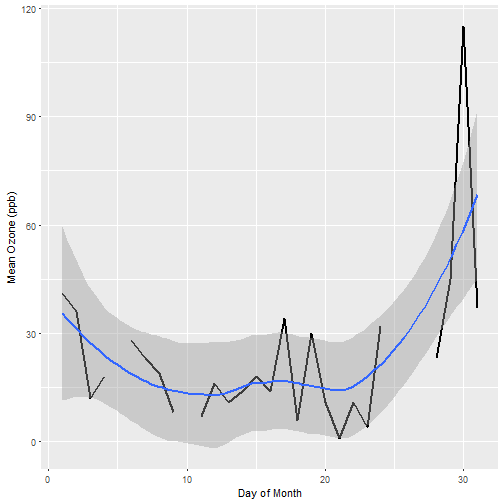

### Used softwares and packages

- R Core Team (2016). R: A language and environment for statistical computing. R Foundation for Statistical Computing, Vienna, Austria. URL https://www.R-project.org/.
- RStudio Team (2016). RStudio: Integrated Development for R. RStudio, Inc., Boston, MA URL http://www.rstudio.com/.
- Winston Chang, Joe Cheng, JJ Allaire, Yihui Xie and Jonathan McPherson (2017). shiny: Web Application Framework for R. R package version 1.0.0. https://CRAN.R-project.org/package=shiny
- H. Wickham (2009). ggplot2: Elegant Graphics for Data Analysis. Springer-Verlag New York.